# COVID 19 DATA ANALYSIS

# 1. INTRODUCTION:

# 2. DATA PROCESSING

i. LOAD AND INSPECT DATA

```python
import pandas as pd
import numpy as np
from unidecode import unidecode
import re
```

```python
#load the dataset
df = pd.read_csv('covid_19_clean_complete.csv.zip')
```

```python
# Inspect the data
print(df.head())
print(df.info())
```

```
                 Province/State Country/Region      Lat      Long        Date  \
0  Australian Capital Territory      Australia -35.4735  149.0124  2020-01-22
1               New South Wales      Australia -33.8688  151.2093  2020-01-22
2            Northern Territory      Australia -12.4634  130.8456  2020-01-22
3                    Queensland      Australia -27.4698  153.0251  2020-01-22
4               South Australia      Australia -34.9285  138.6007  2020-01-22

   Confirmed  Deaths  Recovered  Active       WHO Region  DailyGrowthRate  \
0        0.0     0.0        0.0       0  Western Pacific              0.0
1        0.0     0.0        0.0       0  Western Pacific              0.0
2        0.0     0.0        0.0       0  Western Pacific              0.0
3        0.0     0.0        0.0       0  Western Pacific              0.0
4        0.0     0.0        0.0       0  Western Pacific              0.0

   MortalityRatio  Population  CasesPer100k
0             0.0         NaN           0.0
1             0.0         NaN           0.0
2             0.0         NaN           0.0
3             0.0         NaN           0.0
4             0.0         NaN           0.0
<class 'pandas.core.frame.DataFrame'>
RangeIndex: 14664 entries, 0 to 14663
Data columns (total 14 columns):
 #   Column           Non-Null Count  Dtype
---  ------           --------------  -----
 0   Province/State   14664 non-null  object
 1   Country/Region   14664 non-null  object
 2   Lat              14664 non-null  float64
 3   Long             14664 non-null  float64
 4   Date             14664 non-null  object
 5   Confirmed        14664 non-null  float64
 6   Deaths           14664 non-null  float64
 7   Recovered        14664 non-null  float64
 8   Active           14664 non-null  int64
 9   WHO Region       14664 non-null  object
 10  DailyGrowthRate  14664 non-null  float64
 11  MortalityRatio   14664 non-null  float64
 12  Population       0 non-null      float64
 13  CasesPer100k     14664 non-null  float64
dtypes: float64(9), int64(1), object(4)
memory usage: 1.6+ MB
None
```

```python
df
```

|  | Province/State | Country/Region | Lat | Long | Date | Confirmed | Deaths | Recovered | Active | WHO Region | DailyGrowthRate | MortalityRatio | Population | CasesPer100k |
| --- | --- | --- | --- | --- | --- | --- | --- | --- | --- | --- | --- | --- | --- | --- |
| 0 | Australian Capital Territory | Australia | -35.4735 | 149.0124 | 2020-01-22 | 0.000000 | 0.000000 | 0.000000 | 0 | Western Pacific | 0.000000 | 0.000000 | NaN | 0.0 |
| 1 | New South Wales | Australia | -33.8688 | 151.2093 | 2020-01-22 | 0.000000 | 0.000000 | 0.000000 | 0 | Western Pacific | 0.000000 | 0.000000 | NaN | 0.0 |
| 2 | Northern Territory | Australia | -12.4634 | 130.8456 | 2020-01-22 | 0.000000 | 0.000000 | 0.000000 | 0 | Western Pacific | 0.000000 | 0.000000 | NaN | 0.0 |
| 3 | Queensland | Australia | -27.4698 | 153.0251 | 2020-01-22 | 0.000000 | 0.000000 | 0.000000 | 0 | Western Pacific | 0.000000 | 0.000000 | NaN | 0.0 |
| 4 | South Australia | Australia | -34.9285 | 138.6007 | 2020-01-22 | 0.000000 | 0.000000 | 0.000000 | 0 | Western Pacific | 0.000000 | 0.000000 | NaN | 0.0 |
| ... | ... | ... | ... | ... | ... | ... | ... | ... | ... | ... | ... | ... | ... | ... |
| 14659 | Anguilla | United Kingdom | 18.2206 | -63.0686 | 2020-07-27 | 0.000044 | 0.000000 | 0.000047 | 0 | Europe | 0.000000 | 0.000000 | NaN | 0.0 |
| 14660 | British Virgin Islands | United Kingdom | 18.4207 | -64.6400 | 2020-07-27 | 0.000117 | 0.000176 | 0.000109 | 0 | Europe | 0.000000 | 1.502890 | NaN | 0.0 |
| 14661 | Turks and Caicos Islands | United Kingdom | 21.6940 | -71.7979 | 2020-07-27 | 0.001453 | 0.000353 | 0.000559 | 61 | Europe | 0.020619 | 0.242891 | NaN | 0.0 |
| 14662 | Falkland Islands (Malvinas) | United Kingdom | -51.7963 | -59.5236 | 2020-07-27 | 0.000191 | 0.000000 | 0.000202 | 0 | Europe | 0.000000 | 0.000000 | NaN | 0.0 |
| 14663 | Saint Pierre and Miquelon | France | 46.8852 | -56.3159 | 2020-07-27 | 0.000059 | 0.000000 | 0.000016 | 3 | Europe | 0.000000 | 0.000000 | NaN | 0.0 |

14664 rows × 14 columns

ii. CLEANING DATA

Identifying missing values is crucial for data integrity.

Converting location column to a standard format columns.

Converting date column to standard format.

```python
# Check for missing values
print(df.isnull().sum())
```

```
Province/State         0
Country/Region         0
Lat                    0
Long                   0
Date                   0
Confirmed              0
Deaths                 0
Recovered              0
Active                 0
WHO Region             0
DailyGrowthRate        0
MortalityRatio         0
Population         14664
CasesPer100k           0
dtype: int64
```

```python
# Drop rows with missing values
df = df.dropna()

print(df)
```

```
Empty DataFrame
Columns: [Province/State, Country/Region, Lat, Long, Date, Confirmed, Deaths, Recovered, Active, WHO Region, DailyGrowthRate, MortalityRatio, Population, CasesPer100k]
Index: []
```

```python
df
```

[output not shown]

```python
# Handle missing values
df.fillna({'Province/State': '', 'Country/Region': 'Unknown'}, inplace=True)
```

```python
df
```

|  | Province/State | Country/Region | Lat | Long | Date | Confirmed | Deaths | Recovered | Active | WHO Region | DailyGrowthRate | MortalityRatio | Population | CasesPer100k |
| --- | --- | --- | --- | --- | --- | --- | --- | --- | --- | --- | --- | --- | --- | --- |
| 0 | Australian Capital Territory | Australia | -35.4735 | 149.0124 | 2020-01-22 | 0.000000 | 0.000000 | 0.000000 | 0 | Western Pacific | 0.000000 | 0.000000 | NaN | 0.0 |
| 1 | New South Wales | Australia | -33.8688 | 151.2093 | 2020-01-22 | 0.000000 | 0.000000 | 0.000000 | 0 | Western Pacific | 0.000000 | 0.000000 | NaN | 0.0 |
| 2 | Northern Territory | Australia | -12.4634 | 130.8456 | 2020-01-22 | 0.000000 | 0.000000 | 0.000000 | 0 | Western Pacific | 0.000000 | 0.000000 | NaN | 0.0 |
| 3 | Queensland | Australia | -27.4698 | 153.0251 | 2020-01-22 | 0.000000 | 0.000000 | 0.000000 | 0 | Western Pacific | 0.000000 | 0.000000 | NaN | 0.0 |
| 4 | South Australia | Australia | -34.9285 | 138.6007 | 2020-01-22 | 0.000000 | 0.000000 | 0.000000 | 0 | Western Pacific | 0.000000 | 0.000000 | NaN | 0.0 |
| ... | ... | ... | ... | ... | ... | ... | ... | ... | ... | ... | ... | ... | ... | ... |
| 14659 | Anguilla | United Kingdom | 18.2206 | -63.0686 | 2020-07-27 | 0.000044 | 0.000000 | 0.000047 | 0 | Europe | 0.000000 | 0.000000 | NaN | 0.0 |
| 14660 | British Virgin Islands | United Kingdom | 18.4207 | -64.6400 | 2020-07-27 | 0.000117 | 0.000176 | 0.000109 | 0 | Europe | 0.000000 | 1.502890 | NaN | 0.0 |
| 14661 | Turks and Caicos Islands | United Kingdom | 21.6940 | -71.7979 | 2020-07-27 | 0.001453 | 0.000353 | 0.000559 | 61 | Europe | 0.020619 | 0.242891 | NaN | 0.0 |
| 14662 | Falkland Islands (Malvinas) | United Kingdom | -51.7963 | -59.5236 | 2020-07-27 | 0.000191 | 0.000000 | 0.000202 | 0 | Europe | 0.000000 | 0.000000 | NaN | 0.0 |
| 14663 | Saint Pierre and Miquelon | France | 46.8852 | -56.3159 | 2020-07-27 | 0.000059 | 0.000000 | 0.000016 | 3 | Europe | 0.000000 | 0.000000 | NaN | 0.0 |

14664 rows × 14 columns

```python
# Remove duplicates
df = df.drop_duplicates()
```

```python
df
```

|  | Province/State | Country/Region | Lat | Long | Date | Confirmed | Deaths | Recovered | Active | WHO Region | DailyGrowthRate | MortalityRatio | Population | CasesPer100k |
| --- | --- | --- | --- | --- | --- | --- | --- | --- | --- | --- | --- | --- | --- | --- |
| 0 | Australian Capital Territory | Australia | -35.4735 | 149.0124 | 2020-01-22 | 0.000000 | 0.000000 | 0.000000 | 0 | Western Pacific | 0.000000 | 0.000000 | NaN | 0.0 |
| 1 | New South Wales | Australia | -33.8688 | 151.2093 | 2020-01-22 | 0.000000 | 0.000000 | 0.000000 | 0 | Western Pacific | 0.000000 | 0.000000 | NaN | 0.0 |
| 2 | Northern Territory | Australia | -12.4634 | 130.8456 | 2020-01-22 | 0.000000 | 0.000000 | 0.000000 | 0 | Western Pacific | 0.000000 | 0.000000 | NaN | 0.0 |
| 3 | Queensland | Australia | -27.4698 | 153.0251 | 2020-01-22 | 0.000000 | 0.000000 | 0.000000 | 0 | Western Pacific | 0.000000 | 0.000000 | NaN | 0.0 |
| 4 | South Australia | Australia | -34.9285 | 138.6007 | 2020-01-22 | 0.000000 | 0.000000 | 0.000000 | 0 | Western Pacific | 0.000000 | 0.000000 | NaN | 0.0 |
| ... | ... | ... | ... | ... | ... | ... | ... | ... | ... | ... | ... | ... | ... | ... |
| 14659 | Anguilla | United Kingdom | 18.2206 | -63.0686 | 2020-07-27 | 0.000044 | 0.000000 | 0.000047 | 0 | Europe | 0.000000 | 0.000000 | NaN | 0.0 |
| 14660 | British Virgin Islands | United Kingdom | 18.4207 | -64.6400 | 2020-07-27 | 0.000117 | 0.000176 | 0.000109 | 0 | Europe | 0.000000 | 1.502890 | NaN | 0.0 |
| 14661 | Turks and Caicos Islands | United Kingdom | 21.6940 | -71.7979 | 2020-07-27 | 0.001453 | 0.000353 | 0.000559 | 61 | Europe | 0.020619 | 0.242891 | NaN | 0.0 |
| 14662 | Falkland Islands (Malvinas) | United Kingdom | -51.7963 | -59.5236 | 2020-07-27 | 0.000191 | 0.000000 | 0.000202 | 0 | Europe | 0.000000 | 0.000000 | NaN | 0.0 |
| 14663 | Saint Pierre and Miquelon | France | 46.8852 | -56.3159 | 2020-07-27 | 0.000059 | 0.000000 | 0.000016 | 3 | Europe | 0.000000 | 0.000000 | NaN | 0.0 |

14664 rows × 14 columns

```python
# Standardize date formats
df['Date'] = pd.to_datetime(df['Date'], errors='coerce')

print(df)
```

```
                     Province/State  Country/Region      Lat      Long  \
0      Australian Capital Territory       Australia -35.4735  149.0124
1                   New South Wales       Australia -33.8688  151.2093
2                Northern Territory       Australia -12.4634  130.8456
3                        Queensland       Australia -27.4698  153.0251
4                   South Australia       Australia -34.9285  138.6007
...                             ...             ...      ...       ...
14659                      Anguilla  United Kingdom  18.2206  -63.0686
14660        British Virgin Islands  United Kingdom  18.4207  -64.6400
14661      Turks and Caicos Islands  United Kingdom  21.6940  -71.7979
14662   Falkland Islands (Malvinas)  United Kingdom -51.7963  -59.5236
14663     Saint Pierre and Miquelon          France  46.8852  -56.3159

            Date  Confirmed    Deaths  Recovered  Active       WHO Region  \
0     2020-01-22   0.000000  0.000000   0.000000       0  Western Pacific
```

[output cut: 25 more lines]

```python
df
```

|  | Province/State | Country/Region | Lat | Long | Date | Confirmed | Deaths | Recovered | Active | WHO Region | DailyGrowthRate | MortalityRatio | Population | CasesPer100k |
| --- | --- | --- | --- | --- | --- | --- | --- | --- | --- | --- | --- | --- | --- | --- |
| 0 | Australian Capital Territory | Australia | -35.4735 | 149.0124 | 2020-01-22 | 0.000000 | 0.000000 | 0.000000 | 0 | Western Pacific | 0.000000 | 0.000000 | NaN | 0.0 |
| 1 | New South Wales | Australia | -33.8688 | 151.2093 | 2020-01-22 | 0.000000 | 0.000000 | 0.000000 | 0 | Western Pacific | 0.000000 | 0.000000 | NaN | 0.0 |
| 2 | Northern Territory | Australia | -12.4634 | 130.8456 | 2020-01-22 | 0.000000 | 0.000000 | 0.000000 | 0 | Western Pacific | 0.000000 | 0.000000 | NaN | 0.0 |
| 3 | Queensland | Australia | -27.4698 | 153.0251 | 2020-01-22 | 0.000000 | 0.000000 | 0.000000 | 0 | Western Pacific | 0.000000 | 0.000000 | NaN | 0.0 |
| 4 | South Australia | Australia | -34.9285 | 138.6007 | 2020-01-22 | 0.000000 | 0.000000 | 0.000000 | 0 | Western Pacific | 0.000000 | 0.000000 | NaN | 0.0 |
| ... | ... | ... | ... | ... | ... | ... | ... | ... | ... | ... | ... | ... | ... | ... |
| 14659 | Anguilla | United Kingdom | 18.2206 | -63.0686 | 2020-07-27 | 0.000044 | 0.000000 | 0.000047 | 0 | Europe | 0.000000 | 0.000000 | NaN | 0.0 |
| 14660 | British Virgin Islands | United Kingdom | 18.4207 | -64.6400 | 2020-07-27 | 0.000117 | 0.000176 | 0.000109 | 0 | Europe | 0.000000 | 1.502890 | NaN | 0.0 |
| 14661 | Turks and Caicos Islands | United Kingdom | 21.6940 | -71.7979 | 2020-07-27 | 0.001453 | 0.000353 | 0.000559 | 61 | Europe | 0.020619 | 0.242891 | NaN | 0.0 |
| 14662 | Falkland Islands (Malvinas) | United Kingdom | -51.7963 | -59.5236 | 2020-07-27 | 0.000191 | 0.000000 | 0.000202 | 0 | Europe | 0.000000 | 0.000000 | NaN | 0.0 |
| 14663 | Saint Pierre and Miquelon | France | 46.8852 | -56.3159 | 2020-07-27 | 0.000059 | 0.000000 | 0.000016 | 3 | Europe | 0.000000 | 0.000000 | NaN | 0.0 |

14664 rows × 14 columns

```python
# convert location column to a standard format
df['Country/Region'] = pd.Categorical(df['Country/Region'])

print(df)
```

```
                     Province/State  Country/Region      Lat      Long  \
0      Australian Capital Territory       Australia -35.4735  149.0124
1                   New South Wales       Australia -33.8688  151.2093
2                Northern Territory       Australia -12.4634  130.8456
3                        Queensland       Australia -27.4698  153.0251
4                   South Australia       Australia -34.9285  138.6007
...                             ...             ...      ...       ...
14659                      Anguilla  United Kingdom  18.2206  -63.0686
14660        British Virgin Islands  United Kingdom  18.4207  -64.6400
14661      Turks and Caicos Islands  United Kingdom  21.6940  -71.7979
14662   Falkland Islands (Malvinas)  United Kingdom -51.7963  -59.5236
14663     Saint Pierre and Miquelon          France  46.8852  -56.3159

            Date  Confirmed    Deaths  Recovered  Active       WHO Region  \
0     2020-01-22   0.000000  0.000000   0.000000       0  Western Pacific
```

[output cut: 25 more lines]

```python
df
```

|  | Province/State | Country/Region | Lat | Long | Date | Confirmed | Deaths | Recovered | Active | WHO Region | DailyGrowthRate | MortalityRatio | Population | CasesPer100k |
| --- | --- | --- | --- | --- | --- | --- | --- | --- | --- | --- | --- | --- | --- | --- |
| 0 | Australian Capital Territory | Australia | -35.4735 | 149.0124 | 2020-01-22 | 0.000000 | 0.000000 | 0.000000 | 0 | Western Pacific | 0.000000 | 0.000000 | NaN | 0.0 |
| 1 | New South Wales | Australia | -33.8688 | 151.2093 | 2020-01-22 | 0.000000 | 0.000000 | 0.000000 | 0 | Western Pacific | 0.000000 | 0.000000 | NaN | 0.0 |
| 2 | Northern Territory | Australia | -12.4634 | 130.8456 | 2020-01-22 | 0.000000 | 0.000000 | 0.000000 | 0 | Western Pacific | 0.000000 | 0.000000 | NaN | 0.0 |
| 3 | Queensland | Australia | -27.4698 | 153.0251 | 2020-01-22 | 0.000000 | 0.000000 | 0.000000 | 0 | Western Pacific | 0.000000 | 0.000000 | NaN | 0.0 |
| 4 | South Australia | Australia | -34.9285 | 138.6007 | 2020-01-22 | 0.000000 | 0.000000 | 0.000000 | 0 | Western Pacific | 0.000000 | 0.000000 | NaN | 0.0 |
| ... | ... | ... | ... | ... | ... | ... | ... | ... | ... | ... | ... | ... | ... | ... |
| 14659 | Anguilla | United Kingdom | 18.2206 | -63.0686 | 2020-07-27 | 0.000044 | 0.000000 | 0.000047 | 0 | Europe | 0.000000 | 0.000000 | NaN | 0.0 |
| 14660 | British Virgin Islands | United Kingdom | 18.4207 | -64.6400 | 2020-07-27 | 0.000117 | 0.000176 | 0.000109 | 0 | Europe | 0.000000 | 1.502890 | NaN | 0.0 |
| 14661 | Turks and Caicos Islands | United Kingdom | 21.6940 | -71.7979 | 2020-07-27 | 0.001453 | 0.000353 | 0.000559 | 61 | Europe | 0.020619 | 0.242891 | NaN | 0.0 |
| 14662 | Falkland Islands (Malvinas) | United Kingdom | -51.7963 | -59.5236 | 2020-07-27 | 0.000191 | 0.000000 | 0.000202 | 0 | Europe | 0.000000 | 0.000000 | NaN | 0.0 |
| 14663 | Saint Pierre and Miquelon | France | 46.8852 | -56.3159 | 2020-07-27 | 0.000059 | 0.000000 | 0.000016 | 3 | Europe | 0.000000 | 0.000000 | NaN | 0.0 |

14664 rows × 14 columns

iii. TRANSFORMATION

Normalize Numerical Features and Checking that all numerical features have consistent units.

```python
from sklearn.preprocessing import MinMaxScaler

# Normalize numerical features
scaler = MinMaxScaler()

# Select numerical columns to normalize
numerical_cols = ['Confirmed', 'Deaths', 'Recovered']

# Apply normalization
df[numerical_cols] = scaler.fit_transform(df[numerical_cols])
```

```python
df
```

|  | Province/State | Country/Region | Lat | Long | Date | Confirmed | Deaths | Recovered | Active | WHO Region | DailyGrowthRate | MortalityRatio | Population | CasesPer100k |
| --- | --- | --- | --- | --- | --- | --- | --- | --- | --- | --- | --- | --- | --- | --- |
| 0 | Australian Capital Territory | Australia | -35.4735 | 149.0124 | 2020-01-22 | 0.000000 | 0.000000 | 0.000000 | 0 | Western Pacific | 0.000000 | 0.000000 | NaN | 0.0 |
| 1 | New South Wales | Australia | -33.8688 | 151.2093 | 2020-01-22 | 0.000000 | 0.000000 | 0.000000 | 0 | Western Pacific | 0.000000 | 0.000000 | NaN | 0.0 |
| 2 | Northern Territory | Australia | -12.4634 | 130.8456 | 2020-01-22 | 0.000000 | 0.000000 | 0.000000 | 0 | Western Pacific | 0.000000 | 0.000000 | NaN | 0.0 |
| 3 | Queensland | Australia | -27.4698 | 153.0251 | 2020-01-22 | 0.000000 | 0.000000 | 0.000000 | 0 | Western Pacific | 0.000000 | 0.000000 | NaN | 0.0 |
| 4 | South Australia | Australia | -34.9285 | 138.6007 | 2020-01-22 | 0.000000 | 0.000000 | 0.000000 | 0 | Western Pacific | 0.000000 | 0.000000 | NaN | 0.0 |
| ... | ... | ... | ... | ... | ... | ... | ... | ... | ... | ... | ... | ... | ... | ... |
| 14659 | Anguilla | United Kingdom | 18.2206 | -63.0686 | 2020-07-27 | 0.000044 | 0.000000 | 0.000047 | 0 | Europe | 0.000000 | 0.000000 | NaN | 0.0 |
| 14660 | British Virgin Islands | United Kingdom | 18.4207 | -64.6400 | 2020-07-27 | 0.000117 | 0.000176 | 0.000109 | 0 | Europe | 0.000000 | 1.502890 | NaN | 0.0 |
| 14661 | Turks and Caicos Islands | United Kingdom | 21.6940 | -71.7979 | 2020-07-27 | 0.001453 | 0.000353 | 0.000559 | 61 | Europe | 0.020619 | 0.242891 | NaN | 0.0 |
| 14662 | Falkland Islands (Malvinas) | United Kingdom | -51.7963 | -59.5236 | 2020-07-27 | 0.000191 | 0.000000 | 0.000202 | 0 | Europe | 0.000000 | 0.000000 | NaN | 0.0 |
| 14663 | Saint Pierre and Miquelon | France | 46.8852 | -56.3159 | 2020-07-27 | 0.000059 | 0.000000 | 0.000016 | 3 | Europe | 0.000000 | 0.000000 | NaN | 0.0 |

14664 rows × 14 columns

iv. FEAUTURE ENGINEERING

Daily Growth Rate by calculating the daily growth rate of confirmed cases.

Mortality Ratio Compute deaths as a proportion of confirmed cases.

Cases Per Population If population data is available, we will compute cases per 100,000 people.

```python
# Daily growth rate
df['DailyGrowthRate'] = df.groupby(['Country/Region', 'Province/State'])['Confirmed'].pct_change().fillna(0)

# Mortality ratio
df['MortalityRatio'] = (df['Deaths'] / df['Confirmed']).replace([np.inf, -np.inf], 0).fillna(0)

# Cases per population
# Assuming population data is available as a separate dataset
population_data = {
    'usa': 331002651,  # Example: United States population
    'brazil': 212559417,  # Brazil population
    # Add other countries...
}
df['Population'] = df['Country/Region'].map(population_data)
df['CasesPer100k'] = (df['Confirmed'] / df['Population'] * 100000).fillna(0)
```

```python
df
```

|  | Province/State | Country/Region | Lat | Long | Date | Confirmed | Deaths | Recovered | Active | WHO Region | DailyGrowthRate | MortalityRatio | Population | CasesPer100k |
| --- | --- | --- | --- | --- | --- | --- | --- | --- | --- | --- | --- | --- | --- | --- |
| 0 | Australian Capital Territory | Australia | -35.4735 | 149.0124 | 2020-01-22 | 0.000000 | 0.000000 | 0.000000 | 0 | Western Pacific | 0.000000 | 0.000000 | NaN | 0.0 |
| 1 | New South Wales | Australia | -33.8688 | 151.2093 | 2020-01-22 | 0.000000 | 0.000000 | 0.000000 | 0 | Western Pacific | 0.000000 | 0.000000 | NaN | 0.0 |
| 2 | Northern Territory | Australia | -12.4634 | 130.8456 | 2020-01-22 | 0.000000 | 0.000000 | 0.000000 | 0 | Western Pacific | 0.000000 | 0.000000 | NaN | 0.0 |
| 3 | Queensland | Australia | -27.4698 | 153.0251 | 2020-01-22 | 0.000000 | 0.000000 | 0.000000 | 0 | Western Pacific | 0.000000 | 0.000000 | NaN | 0.0 |
| 4 | South Australia | Australia | -34.9285 | 138.6007 | 2020-01-22 | 0.000000 | 0.000000 | 0.000000 | 0 | Western Pacific | 0.000000 | 0.000000 | NaN | 0.0 |
| ... | ... | ... | ... | ... | ... | ... | ... | ... | ... | ... | ... | ... | ... | ... |
| 14659 | Anguilla | United Kingdom | 18.2206 | -63.0686 | 2020-07-27 | 0.000044 | 0.000000 | 0.000047 | 0 | Europe | 0.000000 | 0.000000 | NaN | 0.0 |
| 14660 | British Virgin Islands | United Kingdom | 18.4207 | -64.6400 | 2020-07-27 | 0.000117 | 0.000176 | 0.000109 | 0 | Europe | 0.000000 | 1.502890 | NaN | 0.0 |
| 14661 | Turks and Caicos Islands | United Kingdom | 21.6940 | -71.7979 | 2020-07-27 | 0.001453 | 0.000353 | 0.000559 | 61 | Europe | 0.020619 | 0.242891 | NaN | 0.0 |
| 14662 | Falkland Islands (Malvinas) | United Kingdom | -51.7963 | -59.5236 | 2020-07-27 | 0.000191 | 0.000000 | 0.000202 | 0 | Europe | 0.000000 | 0.000000 | NaN | 0.0 |
| 14663 | Saint Pierre and Miquelon | France | 46.8852 | -56.3159 | 2020-07-27 | 0.000059 | 0.000000 | 0.000016 | 3 | Europe | 0.000000 | 0.000000 | NaN | 0.0 |

14664 rows × 14 columns

V. SAVE AND INSPECT DATA

```python
# Save the processed dataset
df.to_csv('covid_19_clean_complete.csv.zip', index=False)

# Inspect the processed dataset
print(df.head())
```

```
                 Province/State Country/Region      Lat      Long       Date  \
0  Australian Capital Territory      Australia -35.4735  149.0124 2020-01-22
1               New South Wales      Australia -33.8688  151.2093 2020-01-22
2            Northern Territory      Australia -12.4634  130.8456 2020-01-22
3                    Queensland      Australia -27.4698  153.0251 2020-01-22
4               South Australia      Australia -34.9285  138.6007 2020-01-22

   Confirmed  Deaths  Recovered  Active       WHO Region  DailyGrowthRate  \
0        0.0     0.0        0.0       0  Western Pacific              0.0
1        0.0     0.0        0.0       0  Western Pacific              0.0
2        0.0     0.0        0.0       0  Western Pacific              0.0
3        0.0     0.0        0.0       0  Western Pacific              0.0
4        0.0     0.0        0.0       0  Western Pacific              0.0

   MortalityRatio  Population  CasesPer100k
0             0.0         NaN           0.0
1             0.0         NaN           0.0
2             0.0         NaN           0.0
3             0.0         NaN           0.0
4             0.0         NaN           0.0
```

# 3.EXPLORATORY DATA ANALYSIS (EDA)

i. SUMMARY STATISTICS

```python
# Display summary statistics
print(df.describe())

# Check for correlations
print(df.corr())
```

```
                Lat          Long     Confirmed        Deaths     Recovered  \
count  14664.000000  14664.000000  14664.000000  14664.000000  14664.000000
mean      24.399387     38.808982      0.025210      0.016853      0.013434
std       27.888920     94.424973      0.125098      0.103985      0.096154
min      -51.796300   -135.000000      0.000000      0.000000      0.000000
25%       17.900000    -63.050100      0.000147      0.000000      0.000000
50%       30.796350    102.098650      0.002084      0.000176      0.000419
75%       43.666100    116.414200      0.008131      0.001059      0.003632
max       71.706900    165.618042      1.000000      1.000000      1.000000

             Active  DailyGrowthRate  MortalityRatio  Population  CasesPer100k
count  14664.000000     1.466400e+04    14664.000000         0.0       14664.0
mean     756.591721              inf        0.200175         NaN           0.0
std     4719.014122              NaN        0.428025         NaN           0.0
min      -14.000000    -1.000000e+00        0.000000         NaN           0.0
25%        0.000000     0.000000e+00        0.000000         NaN           0.0
50%        4.000000     0.000000e+00        0.058400         NaN           0.0
75%       59.000000     1.941770e-03        0.183941         NaN           0.0
max    53061.000000              inf       12.023116         NaN           0.0
                      Lat      Long  Confirmed    Deaths  Recovered    Active  \
Lat              1.000000 -0.375388   0.082841  0.097141   0.010245  0.124048
Long            -0.375388  1.000000  -0.002090 -0.040653   0.105253 -0.136888
Confirmed        0.082841 -0.002090   1.000000  0.960537   0.800133  0.635759
Deaths           0.097141 -0.040653   0.960537  1.000000   0.690532  0.703450
Recovered        0.010245  0.105253   0.800133  0.690532   1.000000  0.046064
Active           0.124048 -0.136888   0.635759  0.703450   0.046064  1.000000
DailyGrowthRate  0.002787  0.010566  -0.025229 -0.023236  -0.023493 -0.011821
MortalityRatio   0.009579 -0.196097   0.220509  0.244941   0.119298  0.211071
Population            NaN       NaN        NaN       NaN        NaN       NaN
CasesPer100k          NaN       NaN        NaN       NaN        NaN       NaN

                 DailyGrowthRate  MortalityRatio  Population  CasesPer100k
Lat                     0.002787        0.009579         NaN           NaN
Long                    0.010566       -0.196097         NaN           NaN
Confirmed              -0.025229        0.220509         NaN           NaN
Deaths                 -0.023236        0.244941         NaN           NaN
Recovered              -0.023493        0.119298         NaN           NaN
Active                 -0.011821        0.211071         NaN           NaN
DailyGrowthRate         1.000000       -0.023497         NaN           NaN
MortalityRatio         -0.023497        1.000000         NaN           NaN
Population                   NaN             NaN         NaN           NaN
CasesPer100k                 NaN             NaN         NaN           NaN
```

```python
df
```

|  | Province/State | Country/Region | Lat | Long | Date | Confirmed | Deaths | Recovered | Active | WHO Region | DailyGrowthRate | MortalityRatio | Population | CasesPer100k |
| --- | --- | --- | --- | --- | --- | --- | --- | --- | --- | --- | --- | --- | --- | --- |
| 0 | Australian Capital Territory | Australia | -35.4735 | 149.0124 | 2020-01-22 | 0.000000 | 0.000000 | 0.000000 | 0 | Western Pacific | 0.000000 | 0.000000 | NaN | 0.0 |
| 1 | New South Wales | Australia | -33.8688 | 151.2093 | 2020-01-22 | 0.000000 | 0.000000 | 0.000000 | 0 | Western Pacific | 0.000000 | 0.000000 | NaN | 0.0 |
| 2 | Northern Territory | Australia | -12.4634 | 130.8456 | 2020-01-22 | 0.000000 | 0.000000 | 0.000000 | 0 | Western Pacific | 0.000000 | 0.000000 | NaN | 0.0 |
| 3 | Queensland | Australia | -27.4698 | 153.0251 | 2020-01-22 | 0.000000 | 0.000000 | 0.000000 | 0 | Western Pacific | 0.000000 | 0.000000 | NaN | 0.0 |
| 4 | South Australia | Australia | -34.9285 | 138.6007 | 2020-01-22 | 0.000000 | 0.000000 | 0.000000 | 0 | Western Pacific | 0.000000 | 0.000000 | NaN | 0.0 |
| ... | ... | ... | ... | ... | ... | ... | ... | ... | ... | ... | ... | ... | ... | ... |
| 14659 | Anguilla | United Kingdom | 18.2206 | -63.0686 | 2020-07-27 | 0.000044 | 0.000000 | 0.000047 | 0 | Europe | 0.000000 | 0.000000 | NaN | 0.0 |
| 14660 | British Virgin Islands | United Kingdom | 18.4207 | -64.6400 | 2020-07-27 | 0.000117 | 0.000176 | 0.000109 | 0 | Europe | 0.000000 | 1.502890 | NaN | 0.0 |
| 14661 | Turks and Caicos Islands | United Kingdom | 21.6940 | -71.7979 | 2020-07-27 | 0.001453 | 0.000353 | 0.000559 | 61 | Europe | 0.020619 | 0.242891 | NaN | 0.0 |
| 14662 | Falkland Islands (Malvinas) | United Kingdom | -51.7963 | -59.5236 | 2020-07-27 | 0.000191 | 0.000000 | 0.000202 | 0 | Europe | 0.000000 | 0.000000 | NaN | 0.0 |
| 14663 | Saint Pierre and Miquelon | France | 46.8852 | -56.3159 | 2020-07-27 | 0.000059 | 0.000000 | 0.000016 | 3 | Europe | 0.000000 | 0.000000 | NaN | 0.0 |

14664 rows × 14 columns

ii. TIME-SERIES TRENDS.

```python
import matplotlib.pyplot as plt
import seaborn as sns
```

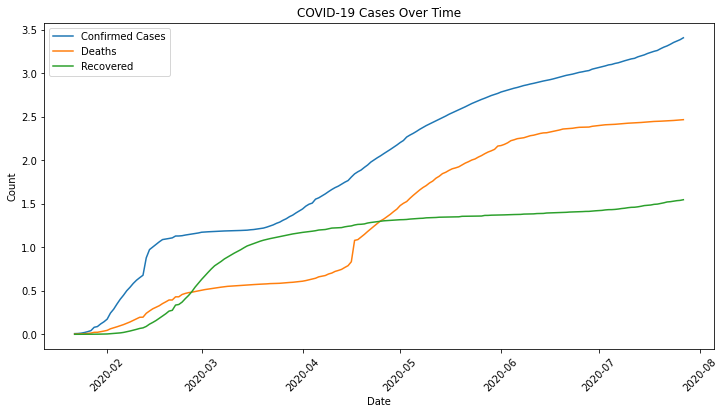

```python
# Plot confirmed cases over time
df_grouped = df.groupby('Date').sum().reset_index()
plt.figure(figsize=(12, 6))
sns.lineplot(data=df_grouped, x='Date', y='Confirmed', label='Confirmed Cases')
sns.lineplot(data=df_grouped, x='Date', y='Deaths', label='Deaths')
sns.lineplot(data=df_grouped, x='Date', y='Recovered', label='Recovered')
plt.title('COVID-19 Cases Over Time')
plt.xlabel('Date')
plt.ylabel('Count')
plt.xticks(rotation=45)
plt.legend()
plt.show()
```

```python
print(df.columns)
```

```
Index(['Province/State', 'Country/Region', 'Lat', 'Long', 'Date', 'Confirmed',
       'Deaths', 'Recovered', 'Active', 'WHO Region', 'DailyGrowthRate',
       'MortalityRatio', 'Population', 'CasesPer100k'],
      dtype='object')
```

iii. BAR CHARTS FOR MORTALITY RATIOS BY COUNTRY

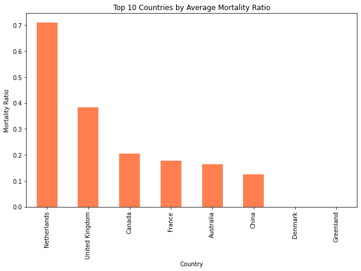

```python
# Bar chart for mortality ratio by top 10 countries
top_countries = df.groupby('Country/Region')['MortalityRatio'].mean().nlargest(10)
plt.figure(figsize=(10, 6))
top_countries.plot(kind='bar', color='coral')
plt.title('Top 10 Countries by Average Mortality Ratio')
plt.ylabel('Mortality Ratio')
plt.xlabel('Country')
plt.show()
```

iv. OUTLIERS AND CORRELATIONS

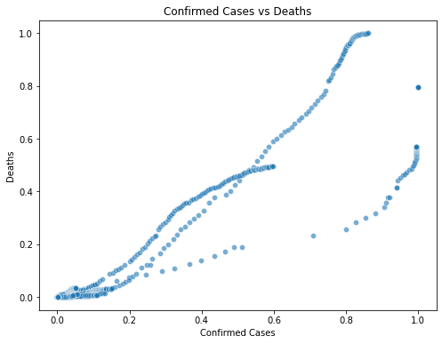

```python
# Scatter plot for Confirmed Cases vs Deaths
plt.figure(figsize=(8, 6))
sns.scatterplot(data=df, x='Confirmed', y='Deaths', alpha=0.6)
plt.title('Confirmed Cases vs Deaths')
plt.xlabel('Confirmed Cases')
plt.ylabel('Deaths')
plt.show()
```

```python
# Check correlation with population density
correlation = df['CasesPer100k'].corr(df['Population'])
print(f"Correlation between Cases per 100k and Population: {correlation}")
```

```
Correlation between Cases per 100k and Population: nan
```

```python
df
```

|  | Province/State | Country/Region | Lat | Long | Date | Confirmed | Deaths | Recovered | Active | WHO Region | DailyGrowthRate | MortalityRatio | Population | CasesPer100k |
| --- | --- | --- | --- | --- | --- | --- | --- | --- | --- | --- | --- | --- | --- | --- |
| 0 | Australian Capital Territory | Australia | -35.4735 | 149.0124 | 2020-01-22 | 0.000000 | 0.000000 | 0.000000 | 0 | Western Pacific | 0.000000 | 0.000000 | NaN | 0.0 |
| 1 | New South Wales | Australia | -33.8688 | 151.2093 | 2020-01-22 | 0.000000 | 0.000000 | 0.000000 | 0 | Western Pacific | 0.000000 | 0.000000 | NaN | 0.0 |
| 2 | Northern Territory | Australia | -12.4634 | 130.8456 | 2020-01-22 | 0.000000 | 0.000000 | 0.000000 | 0 | Western Pacific | 0.000000 | 0.000000 | NaN | 0.0 |
| 3 | Queensland | Australia | -27.4698 | 153.0251 | 2020-01-22 | 0.000000 | 0.000000 | 0.000000 | 0 | Western Pacific | 0.000000 | 0.000000 | NaN | 0.0 |
| 4 | South Australia | Australia | -34.9285 | 138.6007 | 2020-01-22 | 0.000000 | 0.000000 | 0.000000 | 0 | Western Pacific | 0.000000 | 0.000000 | NaN | 0.0 |
| ... | ... | ... | ... | ... | ... | ... | ... | ... | ... | ... | ... | ... | ... | ... |
| 14659 | Anguilla | United Kingdom | 18.2206 | -63.0686 | 2020-07-27 | 0.000044 | 0.000000 | 0.000047 | 0 | Europe | 0.000000 | 0.000000 | NaN | 0.0 |
| 14660 | British Virgin Islands | United Kingdom | 18.4207 | -64.6400 | 2020-07-27 | 0.000117 | 0.000176 | 0.000109 | 0 | Europe | 0.000000 | 1.502890 | NaN | 0.0 |
| 14661 | Turks and Caicos Islands | United Kingdom | 21.6940 | -71.7979 | 2020-07-27 | 0.001453 | 0.000353 | 0.000559 | 61 | Europe | 0.020619 | 0.242891 | NaN | 0.0 |
| 14662 | Falkland Islands (Malvinas) | United Kingdom | -51.7963 | -59.5236 | 2020-07-27 | 0.000191 | 0.000000 | 0.000202 | 0 | Europe | 0.000000 | 0.000000 | NaN | 0.0 |
| 14663 | Saint Pierre and Miquelon | France | 46.8852 | -56.3159 | 2020-07-27 | 0.000059 | 0.000000 | 0.000016 | 3 | Europe | 0.000000 | 0.000000 | NaN | 0.0 |

14664 rows × 14 columns

# 4. MODEL DEVELOPMENT

i. TIME_SERIES MODELS

Predict future confirmed cases using models like ARIMA

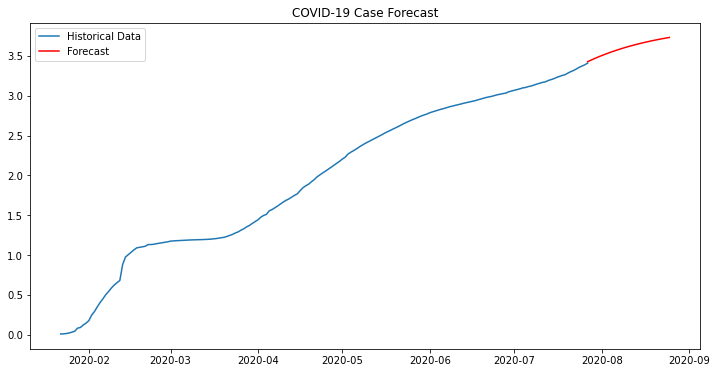

```python
# Ensure index is a DatetimeIndex and set frequency
ts_data.index = pd.to_datetime(ts_data.index)  # Ensure it's a DatetimeIndex
ts_data = ts_data.asfreq('D')  # Explicitly set daily frequency

# Build and fit ARIMA model
from statsmodels.tsa.arima.model import ARIMA

model = ARIMA(ts_data, order=(1, 1, 1))
fit_model = model.fit()

# Forecast and plot
forecast = fit_model.forecast(steps=30)
future_dates = pd.date_range(start=ts_data.index[-1], periods=30, freq='D')
plt.figure(figsize=(12, 6))
plt.plot(ts_data, label='Historical Data')
plt.plot(future_dates, forecast, label='Forecast', color='red')
plt.title('COVID-19 Case Forecast')
plt.legend()
plt.show()
```

ii. CLASSIFICATION MODELS

```python
# Define thresholds for risk classification
high_risk_threshold = 100  # Example: 100 cases per 100k population
low_risk_threshold = 10    # Example: 10 cases per 100k population

# Create RiskCategory column
df['RiskCategory'] = pd.cut(
    df['CasesPer100k'],
    bins=[-1, low_risk_threshold, high_risk_threshold, float('inf')],
    labels=['Low Risk', 'Medium Risk', 'High Risk']
)
```

```python
df
```

|  | Province/State | Country/Region | Lat | Long | Date | Confirmed | Deaths | Recovered | Active | WHO Region | DailyGrowthRate | MortalityRatio | Population | CasesPer100k | RiskCategory |
| --- | --- | --- | --- | --- | --- | --- | --- | --- | --- | --- | --- | --- | --- | --- | --- |
| 0 | Australian Capital Territory | Australia | -35.4735 | 149.0124 | 2020-01-22 | 0.000000 | 0.000000 | 0.000000 | 0 | Western Pacific | 0.000000 | 0.000000 | NaN | 0.0 | Low Risk |
| 1 | New South Wales | Australia | -33.8688 | 151.2093 | 2020-01-22 | 0.000000 | 0.000000 | 0.000000 | 0 | Western Pacific | 0.000000 | 0.000000 | NaN | 0.0 | Low Risk |
| 2 | Northern Territory | Australia | -12.4634 | 130.8456 | 2020-01-22 | 0.000000 | 0.000000 | 0.000000 | 0 | Western Pacific | 0.000000 | 0.000000 | NaN | 0.0 | Low Risk |
| 3 | Queensland | Australia | -27.4698 | 153.0251 | 2020-01-22 | 0.000000 | 0.000000 | 0.000000 | 0 | Western Pacific | 0.000000 | 0.000000 | NaN | 0.0 | Low Risk |
| 4 | South Australia | Australia | -34.9285 | 138.6007 | 2020-01-22 | 0.000000 | 0.000000 | 0.000000 | 0 | Western Pacific | 0.000000 | 0.000000 | NaN | 0.0 | Low Risk |
| ... | ... | ... | ... | ... | ... | ... | ... | ... | ... | ... | ... | ... | ... | ... | ... |
| 14659 | Anguilla | United Kingdom | 18.2206 | -63.0686 | 2020-07-27 | 0.000044 | 0.000000 | 0.000047 | 0 | Europe | 0.000000 | 0.000000 | NaN | 0.0 | Low Risk |
| 14660 | British Virgin Islands | United Kingdom | 18.4207 | -64.6400 | 2020-07-27 | 0.000117 | 0.000176 | 0.000109 | 0 | Europe | 0.000000 | 1.502890 | NaN | 0.0 | Low Risk |
| 14661 | Turks and Caicos Islands | United Kingdom | 21.6940 | -71.7979 | 2020-07-27 | 0.001453 | 0.000353 | 0.000559 | 61 | Europe | 0.020619 | 0.242891 | NaN | 0.0 | Low Risk |
| 14662 | Falkland Islands (Malvinas) | United Kingdom | -51.7963 | -59.5236 | 2020-07-27 | 0.000191 | 0.000000 | 0.000202 | 0 | Europe | 0.000000 | 0.000000 | NaN | 0.0 | Low Risk |
| 14663 | Saint Pierre and Miquelon | France | 46.8852 | -56.3159 | 2020-07-27 | 0.000059 | 0.000000 | 0.000016 | 3 | Europe | 0.000000 | 0.000000 | NaN | 0.0 | Low Risk |

14664 rows × 15 columns

```python
from sklearn.model_selection import train_test_split
from sklearn.ensemble import RandomForestClassifier
from sklearn.metrics import classification_report, confusion_matrix
```

```python
# Example feature set
features = ['CasesPer100k', 'MortalityRatio', 'DailyGrowthRate']
target = 'RiskCategory'  # High-risk or low-risk (predefined)
```

```python
df
```

|  | Province/State | Country/Region | Lat | Long | Date | Confirmed | Deaths | Recovered | Active | WHO Region | DailyGrowthRate | MortalityRatio | Population | CasesPer100k | RiskCategory |
| --- | --- | --- | --- | --- | --- | --- | --- | --- | --- | --- | --- | --- | --- | --- | --- |
| 0 | Australian Capital Territory | Australia | -35.4735 | 149.0124 | 2020-01-22 | 0.000000 | 0.000000 | 0.000000 | 0 | Western Pacific | 0.000000 | 0.000000 | NaN | 0.0 | Low Risk |
| 1 | New South Wales | Australia | -33.8688 | 151.2093 | 2020-01-22 | 0.000000 | 0.000000 | 0.000000 | 0 | Western Pacific | 0.000000 | 0.000000 | NaN | 0.0 | Low Risk |
| 2 | Northern Territory | Australia | -12.4634 | 130.8456 | 2020-01-22 | 0.000000 | 0.000000 | 0.000000 | 0 | Western Pacific | 0.000000 | 0.000000 | NaN | 0.0 | Low Risk |
| 3 | Queensland | Australia | -27.4698 | 153.0251 | 2020-01-22 | 0.000000 | 0.000000 | 0.000000 | 0 | Western Pacific | 0.000000 | 0.000000 | NaN | 0.0 | Low Risk |
| 4 | South Australia | Australia | -34.9285 | 138.6007 | 2020-01-22 | 0.000000 | 0.000000 | 0.000000 | 0 | Western Pacific | 0.000000 | 0.000000 | NaN | 0.0 | Low Risk |
| ... | ... | ... | ... | ... | ... | ... | ... | ... | ... | ... | ... | ... | ... | ... | ... |
| 14659 | Anguilla | United Kingdom | 18.2206 | -63.0686 | 2020-07-27 | 0.000044 | 0.000000 | 0.000047 | 0 | Europe | 0.000000 | 0.000000 | NaN | 0.0 | Low Risk |
| 14660 | British Virgin Islands | United Kingdom | 18.4207 | -64.6400 | 2020-07-27 | 0.000117 | 0.000176 | 0.000109 | 0 | Europe | 0.000000 | 1.502890 | NaN | 0.0 | Low Risk |
| 14661 | Turks and Caicos Islands | United Kingdom | 21.6940 | -71.7979 | 2020-07-27 | 0.001453 | 0.000353 | 0.000559 | 61 | Europe | 0.020619 | 0.242891 | NaN | 0.0 | Low Risk |
| 14662 | Falkland Islands (Malvinas) | United Kingdom | -51.7963 | -59.5236 | 2020-07-27 | 0.000191 | 0.000000 | 0.000202 | 0 | Europe | 0.000000 | 0.000000 | NaN | 0.0 | Low Risk |
| 14663 | Saint Pierre and Miquelon | France | 46.8852 | -56.3159 | 2020-07-27 | 0.000059 | 0.000000 | 0.000016 | 3 | Europe | 0.000000 | 0.000000 | NaN | 0.0 | Low Risk |

14664 rows × 15 columns

```python
# Create train-test split
X = df[features]
y = df[target]
X_train, X_test, y_train, y_test = train_test_split(X, y, test_size=0.2, random_state=42)
```

```python
df
```

|  | Province/State | Country/Region | Lat | Long | Date | Confirmed | Deaths | Recovered | Active | WHO Region | DailyGrowthRate | MortalityRatio | Population | CasesPer100k | RiskCategory |
| --- | --- | --- | --- | --- | --- | --- | --- | --- | --- | --- | --- | --- | --- | --- | --- |
| 0 | Australian Capital Territory | Australia | -35.4735 | 149.0124 | 2020-01-22 | 0.000000 | 0.000000 | 0.000000 | 0 | Western Pacific | 0.000000 | 0.000000 | NaN | 0.0 | Low Risk |
| 1 | New South Wales | Australia | -33.8688 | 151.2093 | 2020-01-22 | 0.000000 | 0.000000 | 0.000000 | 0 | Western Pacific | 0.000000 | 0.000000 | NaN | 0.0 | Low Risk |
| 2 | Northern Territory | Australia | -12.4634 | 130.8456 | 2020-01-22 | 0.000000 | 0.000000 | 0.000000 | 0 | Western Pacific | 0.000000 | 0.000000 | NaN | 0.0 | Low Risk |
| 3 | Queensland | Australia | -27.4698 | 153.0251 | 2020-01-22 | 0.000000 | 0.000000 | 0.000000 | 0 | Western Pacific | 0.000000 | 0.000000 | NaN | 0.0 | Low Risk |
| 4 | South Australia | Australia | -34.9285 | 138.6007 | 2020-01-22 | 0.000000 | 0.000000 | 0.000000 | 0 | Western Pacific | 0.000000 | 0.000000 | NaN | 0.0 | Low Risk |
| ... | ... | ... | ... | ... | ... | ... | ... | ... | ... | ... | ... | ... | ... | ... | ... |
| 14659 | Anguilla | United Kingdom | 18.2206 | -63.0686 | 2020-07-27 | 0.000044 | 0.000000 | 0.000047 | 0 | Europe | 0.000000 | 0.000000 | NaN | 0.0 | Low Risk |
| 14660 | British Virgin Islands | United Kingdom | 18.4207 | -64.6400 | 2020-07-27 | 0.000117 | 0.000176 | 0.000109 | 0 | Europe | 0.000000 | 1.502890 | NaN | 0.0 | Low Risk |
| 14661 | Turks and Caicos Islands | United Kingdom | 21.6940 | -71.7979 | 2020-07-27 | 0.001453 | 0.000353 | 0.000559 | 61 | Europe | 0.020619 | 0.242891 | NaN | 0.0 | Low Risk |
| 14662 | Falkland Islands (Malvinas) | United Kingdom | -51.7963 | -59.5236 | 2020-07-27 | 0.000191 | 0.000000 | 0.000202 | 0 | Europe | 0.000000 | 0.000000 | NaN | 0.0 | Low Risk |
| 14663 | Saint Pierre and Miquelon | France | 46.8852 | -56.3159 | 2020-07-27 | 0.000059 | 0.000000 | 0.000016 | 3 | Europe | 0.000000 | 0.000000 | NaN | 0.0 | Low Risk |

14664 rows × 15 columns

```python
print(X_train.isnull().sum())  # Check for NaNs in each column
print(np.isinf(X_train).sum())  # Check for infinities
```

```
CasesPer100k       0
MortalityRatio     0
DailyGrowthRate    0
dtype: int64
CasesPer100k        0
MortalityRatio      0
DailyGrowthRate    42
dtype: int64
```

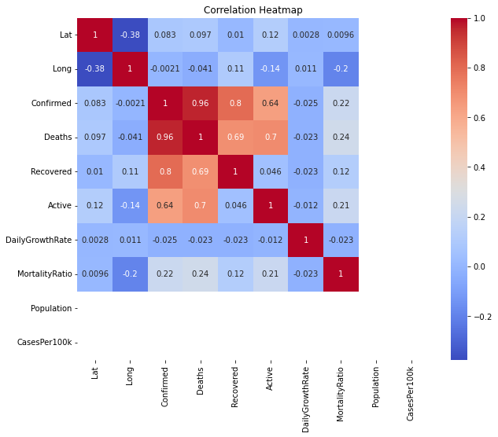

```python
plt.figure(figsize=(10, 8))
sns.heatmap(df.corr(), annot=True, cmap='coolwarm')
plt.title('Correlation Heatmap')
plt.show()
```